# Clustering of NBA Players Using Skills Statistics

## I. Executive Summary

The goal of this study is to group NBA players according to skill statistics using unsupervised clustering method. The data used were NBA player statistics per game for 2006-2019 Regular Seasons, scraped from [Basketball Reference](https://www.basketball-reference.com). After reducing the features into 5 principal components using Truncated SVD, K-means clustering with k=3 clusters algorithm was used due to its scaleability which is good for large data sets, and for the appropriateness of the euclidean metric for the numerical values of the skill statistics data. Three clusters were formed, which are individually coherent in terms of the associated positions and skill set. The **Big Men** cluster are mostly built men who are mostly in the Center and Power Forward positions and excel in blocking and rebounding. The **Scorers and Playmakers** cluster are composed mostly of Point Guard, Small Forward, and Shooting Guard players who excel in raking up points, assists, and steals for the team. Lastly, the **Role Player** cluster are composed of all-around players that do not exceptionally excel in just a few aspects.

## II. Data

The data collected [Basketball Reference](https://www.basketball-reference.com) were NBA player statistics per game for 2006-2019 Regular Seasons. Regular Seasons were collected instead of Play-offs since there are more data points in the former compared to the latter - 82 games for Regular Season and 28 games only for Play-offs. Also, more players are covered by Regular Seasons compared to Play-offs. The metrics gathered where Statistics per Game since this is the most common way to quantify players production over a course of a season. More than a decade of data were used to reflect careers of players, and 2006 was chosen as the starting year in honor of the start of the era when Kobe Bryant wore the number 24.

### A. Data Scraping

The tables were scraped using `BeautifulSoup` package and by looping through the html pages corresponding to variuos years of Regular Seasons. A proxy and `sleep` method from `time` package were used to ensure safe scraping implementation. The pages were read as html using `pandas` and stored in a dictionary with the year as keys and tables as values.

```python
import numpy as np
import pandas as pd
import matplotlib.pyplot as plt

import seaborn as sns
import requests
import sqlite3
from time import sleep
from random import randint
from bs4 import BeautifulSoup as BS
from wordcloud import WordCloud
```

```python
proxy_dict = {
    'http' : 'http://3.112.188.39:8080',
    'https' : 'https://3.112.188.39:8080'
}
```

```python
years = [str(yr) for yr in range(2006, 2020)]

dict_yr = dict()
for year in years:
    url = 'https://www.basketball-reference.com/leagues/NBA_{}_per_game.html'.format(year)
    r = requests.get(url, proxies=proxy_dict).text
    sleep(randint(5,8))
    soup = BS(r, features='lxml')
    table = soup.find_all(name='table')
    df = pd.read_html(str(table))[0]

    # Remove unnecessary headers
    df = df[df.Rk != 'Rk']

    # Convert numerical data into float
    for i in range(7, 30):
        df.iloc[:, i] = df.iloc[:, i].apply(lambda x: float(x))

    # Convert integer data into integer
    for i in [0, 3, 5, 6]:
        df.iloc[:, i] = df.iloc[:, i].apply(lambda x: int(x))

    dict_yr[val] = df

df = pd.DataFrame()
for year in dict_yr.keys():
    df_add = pd.DataFrame(dict_yr[year])
    df_add['year'] = year
    df = pd.concat([df_add, df], axis=0)
```

The long table of player statistics for multiple years (appended tables) was saved to and can be read from a sqlite3 database.

```python
conn = sqlite3.connect('NBA.sqlite')
df.to_sql('NBA_raw_Table_scores', conn, if_exists='replace', index=False)
```

```python
conn = sqlite3.connect('NBA.sqlite')
raw = pd.read_sql(''' SELECT * from NBA_raw_Table_scores''',conn)
raw.head()
```

|  | Rk | Player | Pos | Age | Tm | G | GS | MP | FG | FGA | ... | ORB | DRB | TRB | AST | STL | BLK | TOV | PF | PTS | year |
| --- | --- | --- | --- | --- | --- | --- | --- | --- | --- | --- | --- | --- | --- | --- | --- | --- | --- | --- | --- | --- | --- |
| 0 | 1 | Shareef Abdur-Rahim | PF | 29 | SAC | 72 | 30 | 27.2 | 4.6 | 8.8 | ... | 1.5 | 3.5 | 5.0 | 2.1 | 0.7 | 0.6 | 1.5 | 3.2 | 12.3 | 2006 |
| 1 | 2 | Alex Acker | SG | 23 | DET | 5 | 0 | 7.0 | 0.8 | 3.2 | ... | 0.2 | 0.8 | 1.0 | 0.8 | 0.2 | 0.0 | 0.8 | 0.8 | 1.8 | 2006 |
| 2 | 3 | Malik Allen | PF | 27 | CHI | 54 | 20 | 13.0 | 2.2 | 4.6 | ... | 0.8 | 1.8 | 2.6 | 0.4 | 0.3 | 0.3 | 0.6 | 1.7 | 4.9 | 2006 |
| 3 | 4 | Ray Allen* | SG | 30 | SEA | 78 | 78 | 38.7 | 8.7 | 19.2 | ... | 0.9 | 3.3 | 4.3 | 3.7 | 1.3 | 0.2 | 2.4 | 1.9 | 25.1 | 2006 |
| 4 | 5 | Tony Allen | PG | 24 | BOS | 51 | 9 | 19.2 | 2.5 | 5.4 | ... | 0.6 | 1.5 | 2.2 | 1.3 | 1.0 | 0.4 | 1.3 | 2.5 | 7.2 | 2006 |

5 rows × 31 columns

```python
print("Number of raw entries: {}".format(raw.shape[0]))
print("Number of features: {}".format(raw.shape[1]))
```

```
Number of raw entries: 8390
Number of features: 31
```

### B. Data Pre-processing and Preliminary Feature Extraction

The data gathered consists 8,390 player entries with the following 31 statistics for the Regular Seasons:

- Rk -- Rank
- Pos -- Position
- Age -- Age of Player at the start of February 1st of that season.
- Tm -- Team
- G -- Games
- GS -- Games Started
- MP -- Minutes Played Per Game
- FG -- Field Goals Per Game
- FGA -- Field Goal Attempts Per Game
- FG% -- Field Goal Percentage
- 3P -- 3-Point Field Goals Per Game
- 3PA -- 3-Point Field Goal Attempts Per Game
- 3P% -- FG% on 3-Pt FGAs.
- 2P -- 2-Point Field Goals Per Game
- 2PA -- 2-Point Field Goal Attempts Per Game
- 2P% -- FG% on 2-Pt FGAs.
- eFG% -- Effective Field Goal Percentage
- FT -- Free Throws Per Game
- FTA -- Free Throw Attempts Per Game
- FT% -- Free Throw Percentage
- ORB -- Offensive Rebounds Per Game
- DRB -- Defensive Rebounds Per Game
- TRB -- Total Rebounds Per Game
- AST -- Assists Per Game
- STL -- Steals Per Game
- BLK -- Blocks Per Game
- TOV -- Turnovers Per Game
- PF -- Personal Fouls Per Game
- PTS -- Points Per Game
- year -- NBA Regular Season Year

When rows with missing values are dropped, only 6,934 entries are left in the table.

```python
temp = raw.copy()
temp = temp.dropna()
print("Number of entries left: {}".format(temp.shape[0]))
```

```
Number of entries left: 6934
```

In order to control the quality of data, players who only played less than a game quarter (12 minutes played) in average and those who played a total number of games less than the number required by the [NBA League Leaders Qualifications](https://stats.nba.com/help/statminimums/?fbclid=IwAR0CG5yytJS0NzLWmFRhY8yxvuEaPT2tfxPQ-OOv7i3TDP-aYp0e6GqtAqM) (58 games) were removed from the dataset.

```python
temp = temp[temp.MP >= 12]
temp = temp[temp.G >= 58]

temp = temp.reset_index(drop=True)
```

Next, features which either do not measure playing skills or are redundant to other features - per domain knowledge - were dropped.

```python
df = temp.drop(columns = ['Rk', 'Player', 'Pos', 'Age', 'Tm', 'G', 'GS', 'MP',
                        'FG', 'FGA', 'FG%', '3P%', '2P%', 'eFG%', 'FT%', 'year'])
df.head()
```

|  | 3P | 3PA | 2P | 2PA | FT | FTA | ORB | DRB | TRB | AST | STL | BLK | TOV | PF | PTS |
| --- | --- | --- | --- | --- | --- | --- | --- | --- | --- | --- | --- | --- | --- | --- | --- |
| 0 | 0.1 | 0.3 | 4.5 | 8.5 | 3.0 | 3.9 | 1.5 | 3.5 | 5.0 | 2.1 | 0.7 | 0.6 | 1.5 | 3.2 | 12.3 |
| 1 | 3.4 | 8.4 | 5.3 | 10.9 | 4.2 | 4.6 | 0.9 | 3.3 | 4.3 | 3.7 | 1.3 | 0.2 | 2.4 | 1.9 | 25.1 |
| 2 | 1.6 | 5.0 | 2.8 | 6.8 | 1.6 | 2.3 | 0.6 | 3.5 | 4.0 | 6.7 | 1.6 | 0.2 | 2.5 | 3.1 | 12.1 |
| 3 | 0.5 | 1.9 | 9.0 | 17.8 | 7.2 | 8.9 | 1.5 | 3.4 | 4.9 | 2.7 | 1.1 | 0.5 | 2.7 | 2.9 | 26.5 |
| 4 | 2.5 | 6.8 | 6.8 | 14.1 | 8.2 | 10.0 | 0.7 | 2.8 | 3.5 | 6.1 | 2.0 | 0.3 | 3.7 | 3.6 | 29.3 |

Out of the above features, the most commonly used statistics to describe the overall performance of a player are Points (PTS), Steals (STL), Assists (AST), Rebounds (TRB), Blocks (BLK), and Turnovers (TOV) according to the [NBA Fantasy Scoring](https://www.nba.com/article/2017/10/05/nba-unveils-new-official-fantasy-scoring?fbclid=IwAR3g3qG1PnVht-0ZW1NwXrZH_NfFp1Yjwz0mLXTunoJZXYqbIT9b7kQKXyE). Nonetheless, other features were retained since it was expected that minor components will be removed through dimensionality reduction.

## III. Exploratory Data Analysis

The player positions were data coded in the following manner - Point Guard (PG), Small Forward (SF), Shooting Guard (SG), Power Forward (PF), and Center (C). Some players have played multiple positions that are related/interchangeable, and so there are position entries such as 'PF-C' and 'C-PF'. Positions like this which were just reversed were collapsed together.

```python
# Collapse same 'multiple positions' that are reversed
pseudo_pos = list(temp.Pos)
for i in range(len(pseudo_pos)):
    if pseudo_pos[i] == 'PF-C':
        pseudo_pos[i] = 'C-PF'
    if pseudo_pos[i] == 'SG-PG':
        pseudo_pos[i] = 'PG-SG'
    if pseudo_pos[i] == 'SF-SG':
        pseudo_pos[i] = 'SG-SF'
    if pseudo_pos[i] == 'PF-SF':
        pseudo_pos[i] = 'SF-PF'
```

Due to the different roles of each position in ensuring the success of the team, it could be hypothesized with the aid of domain knowledge that certain skills are associated to certain positions. Thus when clustering players according to skills statistics, it is possible that the resulting clusters will somehow correspond to player positions.

To see if such possible correlations may exist, box plots of the the most commonly used statistics to describe the overall performance of a player were plotted for each position. In the PTS and STL plot, it can be seen that there are exceptionally good SG, PG, and SF players with outlier high points and number of steals. Point Guard players rank exceptionally high in assists and (regrettably,) turnovers, as can be seen in the AST and TOV plot. Center, then PF players, are exceptionally good in rebounding and blocks, as can be seen in the TRB and BLK plots, respectively.

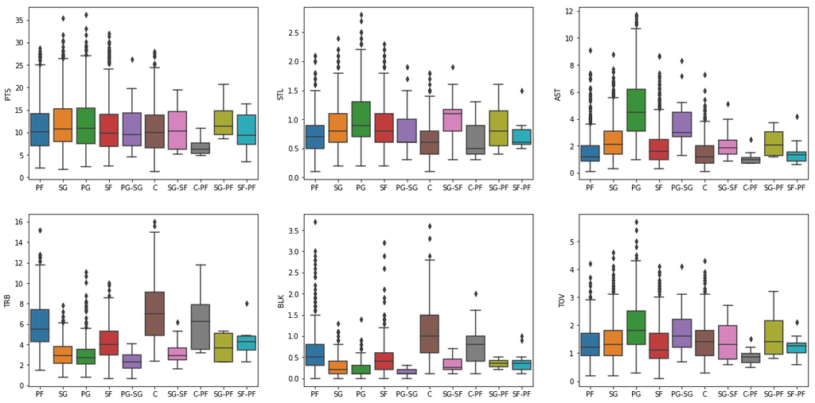

```python
fig, (ax0, ax1) = plt.subplots(2,3,figsize=(20,10))
for i, ax in zip(['PTS', 'STL', 'AST'], ax0):
    sns.boxplot(x=pseudo_pos, y=df[i], ax=ax)
for i, ax in zip(['TRB', 'BLK', 'TOV'], ax1):
    sns.boxplot(x=pseudo_pos, y=df[i], ax=ax)
```

If there appears to be some correlation between the resulting clusters and positions, then it must be checked if the clusters would also reflect the observations in the statistics per position gathered from these exploratory plots.

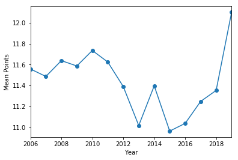

```python
ser = temp.groupby('year')['PTS'].mean()
ser.plot(marker='o')
plt.xlabel('Year')
plt.ylabel('Mean Points');
```

To check on this observation, unsupervised clustering was done separately for the years prior 2014 and for the years after. The insights gathered from the separated clustering were the same as those gained from the results of this study wherein all of the years were considered in clustering, and so were not included anymore in this study.

## IV. Methodology

```python
from sklearn.preprocessing import StandardScaler
from sklearn.decomposition import TruncatedSVD
from sklearn.manifold import TSNE
```

**The entire project workflow is as follows:**

1. Scaling of Vector Space Representation
2. Dimensionality Reduction using Truncated SVD
3. Unsupervised Clustering Using K-Means

### 1. Scaling of Vector Space Representation

**Need for Scaling:**

Any machine learning task involves working with several features. Most of the times these features are extremely different from each other both in magnitude and meaning. What scaling does that it reduces the effects of variation among the features so that a particular feature does not skew our model. To put in simpler terms scaling ensures that we are not adding "apples and oranges", so to speak.

**The general methods of Scaling:**

- **Standard Scaler:**

Standardization is a form of normalization where we transform each value $x$ to their $z$-score,

$$z = \frac{x-\bar x}{\sigma},$$

where $\bar x$ is the mean of that feature and $\sigma$ is the standard deviation of that feature. If you perform this on all features then all features would have a mean of 0 and a standard deviation of 1. This normalization works best if the distribution is at least symmetric.

- **Min-Max Scaler:**

Min-max scaling rescales the feature values into the range [0, 1] by following the transformation,

$$x' = \frac{x - x_\text{min}}{x_\text{max}-x_\text{min}}.$$

This scaling is useful if the values are bounded and there are no outliers.

```python
class MinMax:
    def __init__(self, df):
        """Store the minimum and maximum values of each column"""
        self.min = df.min()
        self.max = df.max()

    def minmax(self, values):
        """Standard values per column"""
        return (values - self.min)/(self.max - self.min)
```

```python
scaler = MinMax(df)
df_scaled = scaler.minmax(df)
df_scaled.head()
```

|  | 3P | 3PA | 2P | 2PA | FT | FTA | ORB | DRB | TRB | AST | STL | BLK | TOV | PF | PTS |
| --- | --- | --- | --- | --- | --- | --- | --- | --- | --- | --- | --- | --- | --- | --- | --- |
| 0 | 0.019608 | 0.022727 | 0.425743 | 0.368664 | 0.309278 | 0.327586 | 0.264151 | 0.283019 | 0.281046 | 0.172414 | 0.222222 | 0.162162 | 0.250000 | 0.742857 | 0.316092 |
| 1 | 0.666667 | 0.636364 | 0.504950 | 0.479263 | 0.432990 | 0.387931 | 0.150943 | 0.264151 | 0.235294 | 0.310345 | 0.444444 | 0.054054 | 0.410714 | 0.371429 | 0.683908 |
| 2 | 0.313725 | 0.378788 | 0.257426 | 0.290323 | 0.164948 | 0.189655 | 0.094340 | 0.283019 | 0.215686 | 0.568966 | 0.555556 | 0.054054 | 0.428571 | 0.714286 | 0.310345 |
| 3 | 0.098039 | 0.143939 | 0.871287 | 0.797235 | 0.742268 | 0.758621 | 0.264151 | 0.273585 | 0.274510 | 0.224138 | 0.370370 | 0.135135 | 0.464286 | 0.657143 | 0.724138 |
| 4 | 0.490196 | 0.515152 | 0.653465 | 0.626728 | 0.845361 | 0.853448 | 0.113208 | 0.216981 | 0.183007 | 0.517241 | 0.703704 | 0.081081 | 0.642857 | 0.857143 | 0.804598 |

### B. Dimensionality Reduction

**Dimensionality Reduction:** A typical machine learning data set is prone to many challenges and high number of features/dimensions is one of them. The term is **"Curse of Dimensionality"** is notorious in all of data science. Thus its in our best interest to try and reduce the dimensions of our data set without loosing substantial information. There is always a trade off between computational complexity vs the amount of information we wish to retain.

The most popular dimensionality reduction algorithms are:

- Principal Component Analysis (PCA)
- Singular Vector Dimensionality Reduction (SVD or Latent Semantic Analysis (LSA))
- Non-negative Matrix factorization (NMF)

In our analysis we have used Truncated SVD which is nothing but SVD where we are restricting the number of singular values/ right singular vectors to represent our original design matrix.

**Singular Vector Decomposition**

The singular value decomposition of a matrix A is the factorization of A into the product of three matrices $$A = UDV^T$$ where the columns of U and V are orthonormal and the matrix D is diagonal with positive real entries. When we select only top k singular values and their corresponding singular vectors our process becomes **Truncated SVD**. Please note that Truncated SVD yields exactly the same results as PCA for a standard scaler normalization.

```python
lsa_full = TruncatedSVD(min(df_scaled.shape)-1, random_state=1011)
trunc_full = lsa_full.fit_transform(df_scaled)
```

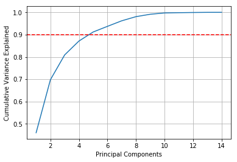

```python
plt.plot(np.arange(1, len(lsa_full.explained_variance_ratio_) + 1),
         lsa_full.explained_variance_ratio_.cumsum())
plt.xlabel('Principal Components')
plt.ylabel('Cumulative Variance Explained')
plt.axhline(0.9, 0, 6000, color ='red', linestyle='--')
plt.grid(True)
```

```python
th = 0.9
PC = np.searchsorted(lsa_full.explained_variance_ratio_.cumsum(), th) + 1
print("Number of Principal Components for {}% Variance = {}".format(th*100, PC))
```

```
Number of Principal Components for 90.0% Variance = 5
```

**Choice of Hyper-Parameter for SVD**

The number of components to use for SVD remains our single most important choice of hyper-parameter. Typically we choose the number of components such that the variance explained is almost 80%-90%. Fo r our analysis we have chosen 90% variance explained as our desired criteria which leads us to **selecting 5 components** for our analysis.

```python
lsa = TruncatedSVD(PC, random_state=1208)
trunc = lsa.fit_transform(df_scaled)
```

### C. Unsupervised Clustering Using K-Means

- **K-Means Clustering**

  The simplest and most popular representative-based clustering method is $k$-means clustering. In this method, the distance function is the L2-norm or the squared sum error (SSE), which is just the square of the L2 norm. The representative is chosen to be the mean of the points in the cluster.

  Why the mean? Representative-based clustering methods, with $k$ clusters, actually try to minimize the objective function $Q = \sum_{j=1}^k Q_j$ where $Q_j = \sum_{x_i \in C_j} Dist(x_i, y_j)$. For $k$-means,

  $$ Q_j = \sum_{x_i \in C_j} (x_i - y_j)^2. $$

  What should be the value of $y_j$ to minimize $Q_j$? It turns out, it's the mean.

  How are the representatives initially selected? The two most common approaches are:
  - randomly assign each data point to a cluster then compute the cluster mean;
  - pick $k$ data points and set them as the cluster representative.

    The first approach tends to make the representatives closer to the center while the other approach tends to spread them out. There are slight differences in terms of performance but either can be chosen for most cases.

    The algorithm has converged if the cluster labels of points do not change after a step. The **time complexity of K-means** is $O(nkid)$ where n is the number of data points, k is the number of clusters, i is the number of iterations and d is the dimension of the design matrix.

**K-means was chosen due to its scaleability which is good to use for large data sets, and for the appropriateness of the euclidean metric for the numerical values of the skill statistics data.**

- **Choice of Hyper-Parameters**

The choice of the hyper-parameter K remains the single most important criteria for clustering. We have used a variety of internal - criterias for this purpose, as explained in the MSDS 2020 DMW Notebooks on Representative-Based Clustering.

1. **Calinski-Harabasz Index:**

   The Calinski-Harabasz index (𝐶𝐻) evaluates the cluster validity based on the average between- and withincluster sum of squares. It measures separation based on the maximum distance between cluster centers, and measures compactness based on the sum of distances between objects and their cluster center. $$s(K) = \frac{B(K)/(K-1)}{W(K)/(n-K)}$$

   where $B(K)$ is the between group dispersion matrix and $W(K)$is the within-cluster dispersion matrix defined by:

   $$B(K) = \sum_{k=1}^K n_k \lvert\lvert \bar x_k - \bar x \rvert\rvert_2^2,$$ $$W(K) = \sum_{k=1}^K \sum_{x \in C_k} \lvert\lvert x - \bar x_k \rvert\rvert_2^2,$$

   with $n$ be the number of points in our data, $C_k$ be the set of points in cluster $k$, $\bar x_k$ be the center of cluster $k$, $\bar x$ be the center of all points, $n_k$ be the number of points in cluster $k$ and $n$ be the number of points. The higher the value of this measure, the more defined the clusters are.
1. **Silhouette Coefficient:**

   Let $Davg^{in}_i$ be the average distance of $x_i$ to data points within the cluster of $x_i$, and $Dmin^{out}_i$ be the smallest average distance to points other than its own cluster. The silhouette coefficient $S_i$ for the $i$th data point specific to the ith object, is as follows: $$ S_i = \frac{Dmin^{out}_i − Davg^{in}_i}{\max\{{Dmin^{out}_i}, Davg^{in}_i\}} $$ The overall silhouette coefficient is the average of $S_i$. Its value is in the the range (−1,1). Large positive values indicate highly separated clustering, and negative values are indicative of some level of “mixing” of data points from different clusters. This is because $Dmin^{out}_i$ will be less than $Davg^{in}_i$ only in cases where data point $x_i$ is closer to at least one other cluster than its own cluster. One advantage of this coefficient is that the absolute values provide a good intuitive feel of the quality of the clustering.
1. **Intra-Inter cluster Distance ratio:**

   We sample $r$ pairs of data points from the underlying data. We then take the ratio of the average distance of pairs $P$ that belong to the same cluster, and the average distance of pairs $Q$ that belong to different clusters: $$ Intra/Inter = \frac{\sum_{(x_i, x_j) \in P)} Dist(x_i, x_j)/\left|P\right|}{\sum_{(x_i, x_j) \in Q)} Dist(x_i, x_j)/\left|Q\right|}. $$ Small values of this measure indicate better clustering behavior.
1. **Sum of squares distances to centroids**: In the case of $k$-means and other representative-based methods, this is $Q$ and corresponds to the sum of squares distances to the representative points. This is given by the `inertia_` property of `KMeans`. Smaller values suggest better clustering. This is optimized for distance-based algorithms.

```python
from sklearn.cluster import KMeans
from scipy.spatial.distance import euclidean
from sklearn.metrics import calinski_harabaz_score, silhouette_score
```

```python
def intra_to_inter(X, y, dist, r):
    """Compute intracluster to intercluster distance ratio

    Parameters
    ----------
    X : array
        Design matrix with each row corresponding to a point
    y : array
        Class label of each point
    dist : callable
        Distance between two points. It should accept two arrays, each
        corresponding to the coordinates of each point
    r : integer
        Number of pairs to sample

    Returns
    -------
    ratio : float
        Intracluster to intercluster distance ratio
    """
    dist_P = []; dist_Q = []
    np.random.seed(11)
    for i, j in np.random.randint(low=0, high=len(y), size=[r,2]):
        if i == j:
            continue
        elif y[i] == y[j]:
            dist_P.append(dist(X[i], X[j]))
        else:
            dist_Q.append(dist(X[i], X[j]))
    ratio = np.mean(dist_P)/np.mean(dist_Q)
    return ratio

def cluster_range(X, clusterer, k_start, k_stop, actual=None):
    """Compute cluster labels, and internal and external validation values
    for different number of clusters using k-means clustering.

    Parameters
    ----------
    X : array
        Design matrix
    clusterer :
        Clustering object
    k_start : int
        Minimum number of clusters
    k_stop : int
        Maximum number of clusters
    actual : array
        Ground-truth labels

    Returns
    -------
    res : dict
        Dictionary of internal validation valuesre lists of results for
        different k's.
    """

    ys = []
    inertias = []; chs = []; iidrs = []; scs = []
    ps = []; amis = []; ars = []

    for k in range(k_start, k_stop+1):
        clusterer.n_clusters = k

        # Cluster labels
        y = clusterer.fit_predict(X)

        # Internal validation values
        inertias.append(clusterer.inertia_)
        chs.append(calinski_harabaz_score(X, y))
        np.random.seed(11)
        iidrs.append(intra_to_inter(X, y, euclidean, 50))
        scs.append(silhouette_score(X, y))

    res =  dict(zip(['Sum of Squared Error', 'Calinski Harabasz Index',
                     'Intra/Intercluster Distance Ratio', 'Silhouette Score'],
            [inertias, chs, iidrs, scs]))

    return res

def plot_internal(validation, k_start, k_stop, k_spec):
    """Plot internal validation values

    Parameters
    ----------
    validation : dict
        Internal Validation Values
    k_start : int
        Minimum number of clusters
    k_stop : int
        Maximum number of clusters
    k_spec : int
        Chosen k to plot vertical line of

    Returns
    -------
    fig
    """
    ks = range(k_start, k_stop+1)
    fig, (ax1, ax2, ax3, ax4) = plt.subplots(1, 4, figsize=(20, 5))
    for j, ax in zip(validation, (ax1, ax2, ax3, ax4)):
        ax.plot(ks, validation[j], 'o--')
        ax.set_ylabel(j);
        ax.set_xlabel('Number of Clusters')
        ax.grid(True)
        ax.axvline(k_spec, linestyle='--', color='red')
    fig.suptitle('Internal Validation Values at Different k Clusters',
                 fontsize=20)
    fig.tight_layout(rect=[0, 0, 1, 0.9])
    plt.close()

    return fig
```

Using the above code, the optimal number of clusters was determined by plotting various internal validation values at different k-number of clusters.

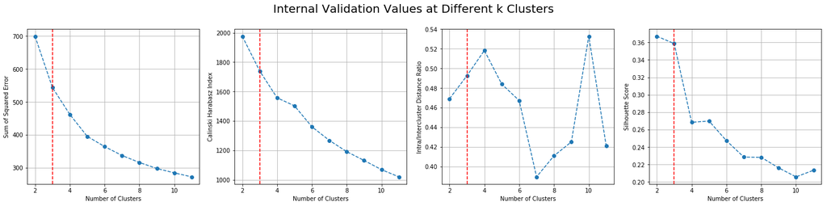

```python
internals = cluster_range(trunc, KMeans(random_state=0), 2, 11);
plot_internal(internals, 2, 11, 3)
```

From the above plots, the number of clusters chosen is: **$$k=3$$** since it represents the highest drop in Sum of Squared Error, a high Calinski Harabasz Index, the elbow of the Silhouette Score before it drops into a desirable low value, and a Intracluster to Intercluster Distance Ratio that even though is not the lowest, is not the highest either.

The hard clustering predictions were made using a K-means algorithm with parameter n-clusters=3, giving us a *parsimonous* amount of clusters.

```python
y_predict = KMeans(n_clusters=3, random_state=0).fit_predict(trunc)
```

**The design matrix was then visualized using t-distributed Stochastic Neighbor Embedding (TSNE) to see how good the clustering were.** This is a state of the art technique to visualize the data in two dimensions. This is specially useful for non-linear data. It is important to understand that t-SNE is not a dimensionality reduction algorithm but just a visual aid for plotting in two dimensions. The time complexity of T-SNE is $O(n^2)$ hence it is computationally expensive.

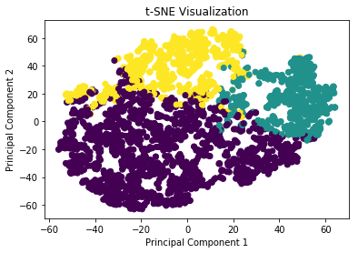

```python
tsne = TSNE(random_state=1208).fit_transform(trunc)
plt.scatter(tsne[:,0], tsne[:,1], c = y_predict);
plt.xlabel('Principal Component 1')
plt.ylabel('Principal Component 2')
plt.title('t-SNE Visualization');
```

The t-SNE visualization showed that the clusters were *separated* and somewhat *compact*. To check if the clusters were *balanced*, the percentage of data points per each cluster were computed.

```python
for cl in set(y_predict):
    cluster = df_scaled[y_predict==cl]
    print("Cluster {} : {:0.2f}% of data points".format(cl, cluster.shape[0]/df_scaled.shape[0]*100))
```

```
Cluster 0 : 58.02% of data points
Cluster 1 : 19.52% of data points
Cluster 2 : 22.46% of data points
```

Cluster 0 was heavy compared to the other clusters, representing about 60% of the data points. The reason for this will be explained later on the next section.

### D. Analysis and Results of Clusters

Using histograms, it was checked whether the resulting clusters corresponded to certain positions.

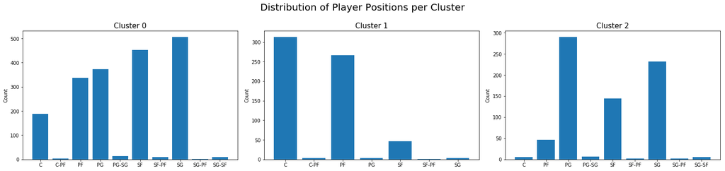

```python
fig, axs = plt.subplots(1,3,figsize=(21,5))
for cl, ax in zip(set(y_predict), axs):
    cluster = np.array(pseudo_pos)[y_predict==cl]
    counts = np.unique(cluster, return_counts=True)
    ax.bar(counts[0], counts[1])
    ax.set_ylabel('Count')
    ax.set_title("Cluster {}".format(cl), fontsize=15)
fig.suptitle('Distribution of Player Positions per Cluster', fontsize=20);
fig.tight_layout(rect=[0, 0, 1, 0.9])
```

Cluster 1 was dominated by Center and Power Forward (C, PF) positions, while Cluster 2 was dominated by Point Guard, Shooting Guard, and Small Forward (PG, SG, SF) positions. No particular position dominated Cluster 0. From these observations, it can be hypothesized that the clusters could be interpreted as follows:

- Cluster 0: **Role Players**
- Cluster 1: **Big Men** (C, PF)
- Cluster 2: **Scorers and Playmakers** (PG, SG, SF)

To check if this interpretations make sense, the stats commonly associated with the cluster labels were plotted to verify if the cluster in question indeed excels in those stats. For starters, the large stature of **Big Men** makes them ideal for C/PF positions since their height would be useful in blocking and rebounding.

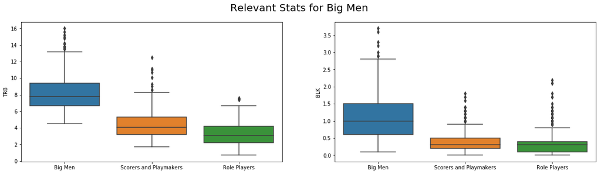

```python
# Replace cluster indices with cluster labels
y_label = {0:'Role Players', 1:'Big Men', 2: 'Scorers and Playmakers'}
y_pred_label = [y_label[i] for i in y_predict]

# Plot relevant stats for "Big Men" cluster
fig, axs = plt.subplots(1, 2, figsize = (20, 5))
for i, ax in zip(['TRB', 'BLK'], axs):
    sns.boxplot(x=y_pred_label, y=df[i], ax=ax)
fig.suptitle('Relevant Stats for Big Men', fontsize=20);
```

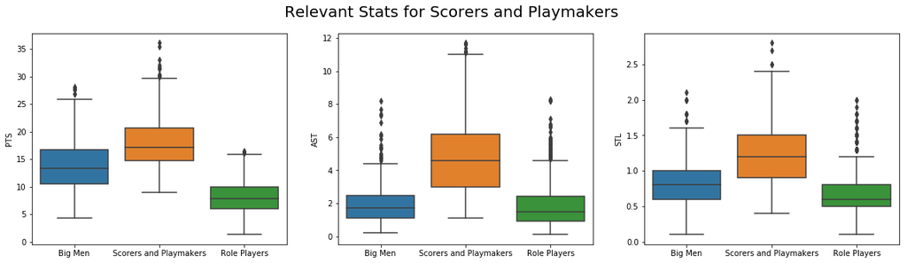

```python
# Plot relevant stats for "Scorers and Playmakers" cluster
fig, axs = plt.subplots(1, 3, figsize = (20, 5))
for i, ax in zip(['PTS', 'AST', 'STL'], axs):
    sns.boxplot(x=y_pred_label, y=df[i], ax=ax)
fig.suptitle('Relevant Stats for Scorers and Playmakers', fontsize=20);
```

Indeed, **Scorers and Playmakers** excel over other clusters in the aforementioned statistics. They also have high Steals per Game (STL) stats, which is not surprising for PG, SF, and SG positions. Lastly, **Role Players** do not specifically overly-excel in particular statistics as they have general roles to complete the needs of the team. These roles can include 3-point shooting (3P) and stealing, among others.

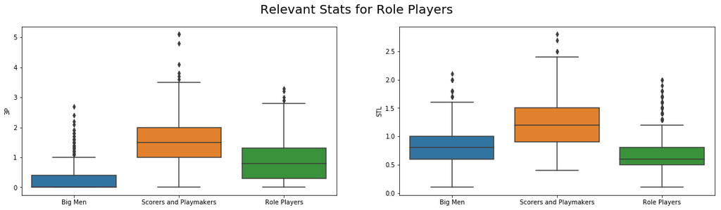

```python
# Plot relevant stats for "Scorers and Playmakers" cluster
fig, axs = plt.subplots(1, 2, figsize = (20, 5))
for i, ax in zip(['3P', 'STL'], axs):
    sns.boxplot(x=y_pred_label, y=df[i], ax=ax)
fig.suptitle('Relevant Stats for Role Players', fontsize=20);
```

**Role Players** do not necessarily excel in the above statistics, but they are not doing bad either. This is because they are expected to perform many functions, hence the name given to their cluster. They are remarkable players in that they are not good only in certain statistics. This can explain why no particular position dominated this cluster.

To further check if players in these clusters are associated with the positions and statistics discussed, an exemplar of 20 players were picked from each cluster, based on overall performance computed through the [*Fantasy Score*](https://www.nba.com/article/2017/10/05/nba-unveils-new-official-fantasy-scoring?fbclid=IwAR3g3qG1PnVht-0ZW1NwXrZH_NfFp1Yjwz0mLXTunoJZXYqbIT9b7kQKXyE) - a linear combination of the player statistics.

```python
fantasy = 1*df.PTS + 3*df.STL + 1.2*df.TRB + 3*df.BLK + 1.5*df.AST + -1*df.TOV
temp['FS'] = fantasy
temp['label'] = y_pred_label
```

```python
exemplars = pd.DataFrame()
for lb in ['Big Men', 'Scorers and Playmakers', 'Role Players']:
    cl = temp[temp.label == lb].loc[:,['Player', 'FS']]
    cl = cl.groupby('Player').sum()
    exemplars[lb] = list(cl.sort_values('FS', ascending = False).index)[:20]
exemplars
```

|  | Big Men | Scorers and Playmakers | Role Players |
| --- | --- | --- | --- |
| 0 | Pau Gasol | LeBron James | Kyle Korver |
| 1 | Dwight Howard | Chris Paul | Matt Barnes |
| 2 | LaMarcus Aldridge | Kevin Durant | Marvin Williams |
| 3 | Tim Duncan | Russell Westbrook | Courtney Lee |
| 4 | Josh Smith | Carmelo Anthony | Tayshaun Prince |
| 5 | Zach Randolph | Kobe Bryant | Jared Dudley |
| 6 | Al Horford | James Harden | Boris Diaw |
| 7 | Paul Millsap | Dwyane Wade | Shane Battier |
| 8 | Chris Bosh | Stephen Curry | Danny Green |
| 9 | David West | Monta Ellis | Corey Brewer |
| 10 | Anthony Davis | Deron Williams | Marco Belinelli |
| 11 | Kevin Garnett | DeMar DeRozan | Vince Carter |
| 12 | Andre Drummond | Kyle Lowry | Al-Farouq Aminu |
| 13 | Marc Gasol | Tony Parker | Channing Frye |
| 14 | Al Jefferson | Andre Iguodala | José Calderón |
| 15 | Shawn Marion | Damian Lillard | Trevor Ariza |
| 16 | DeMarcus Cousins | Paul George | D.J. Augustin |
| 17 | Thaddeus Young | Paul Pierce | Thabo Sefolosha |
| 18 | Serge Ibaka | Joe Johnson | J.R. Smith |
| 19 | Giannis Antetokounmpo | Kemba Walker | C.J. Miles |

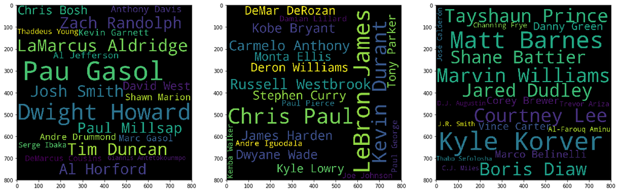

```python
names = dict()
for lb in ['Big Men', 'Scorers and Playmakers', 'Role Players']:
    cl = temp[temp.label == lb].loc[:,['Player', 'FS']]
    cl = cl.groupby('Player').sum()
    cl = cl.sort_values('FS', ascending = False)[:20]
    names[lb] = dict(zip(cl.index, [int(x) for x in round(cl.FS)]))

fig, axs = plt.subplots(1, 3, figsize=(21, 7))
for i, ax in zip(['Big Men', 'Scorers and Playmakers', 'Role Players'], axs):
    wordcloud = WordCloud(width=800, height=800,
                background_color='black',
                min_font_size = 10).generate_from_frequencies(names[i])
    ax.imshow(wordcloud)
```

Indeed, the player names in each cluster are famous for the respective skills and positions associated to the cluster they belong to.

## V. Insights

Three clusters were formed, which are individually coherent in terms of the associated positions and skill set. The **Big Men** cluster are mostly built men who are mostly in the Center and Power Forward positions and excel in blocking and rebounding. The **Scorers and Playmakers** cluster are composed mostly of Point Guard, Small Forward, and Shooting Guard players who excel in raking up points, assists, and steals for the team. Lastly, the **Role Player** cluster are composed of all-around players that do not exceptionally excel in just a few aspects. This could explain why around 58% of the data points went into this cluster, as only a few could become very exceptional rebounders/blockers or scorers/playmakers.

### VI. References

1. [Basketball Reference](https://www.basketball-reference.com/)
2. [NBA Fantasy Scoring](https://www.nba.com/article/2017/10/05/nba-unveils-new-official-fantasy-scoring?fbclid=IwAR3g3qG1PnVht-0ZW1NwXrZH_NfFp1Yjwz0mLXTunoJZXYqbIT9b7kQKXyE)
3. [NBA Advanced Stats](https://stats.nba.com/help/statminimums/?fbclid=IwAR0CG5yytJS0NzLWmFRhY8yxvuEaPT2tfxPQ-OOv7i3TDP-aYp0e6GqtAqM)
4. AIM MSDS 2020 DMW Notebook on Representative-Based Clustering

### VII. Acknowledgements

1. Prof. Christian C. Alis
2. Prof. Eduardo L. David Jr.
3. Prof. Erika T. Legara
4. MSDS 2020 Cohort